# Data 607 Project 2

Kim Koon

2024-10-06

### Load packages

```r
library(tidyverse)
library(sqldf)
```

## Overview / Introduction

For this project, I chose two weather related datasets and resubmitted my Homework 5 assignment. The two weather related datasets were from NOAA and NCAA. To collect this data, I created a web scraper in Python which pulled the data from the websites and formatted it into a dataframe. From there, I am able to pull the data into RStudio and begin the process of data cleaning.

The NOAA dataset contained data of historic storms. It is incredibly messy, with inconsistent format within many columns. Multiple columns have more than one piece of data, and there are also many missing values. The data includes date, the name of the storm (in most cases), the level of surge, various impact variables, and more. The NCAA dataset contains data on monthly snowfall in Buffalo, with data spanning back decades. The scraped data has repeated headers and some “missing” data, indicated by a T which represents trace amounts of snowfall that was not measurable.

## Historic Storms Dataset: Create a CSV file that includes all of the information

For my first dataset, I used the historical storms data from NOAA. This dataset includes historic named storms from the 2010’s to current day. To create the CSV file, I used BeautifulSoup to scrape the data from the NOAA website directly.

```python
import re
from bs4 import BeautifulSoup
import requests
import pandas as pd
import numpy as np

full_url = "https://vlab.noaa.gov/web/mdl/historic-storms"
print(full_url)
page = requests.get(full_url, headers={"User-Agent": "Mozilla/5.0 (X11; CrOS x86_64 12871.102.0) AppleWebKit/537.36 (KHTML, like Gecko) Chrome/81.0.4044.141 Safari/537.36"}).text
soup = BeautifulSoup(page, "html.parser")

pre_tags = []
index = 0

allData = soup.find_all('pre')

for i in allData:
    pre_tags.insert(len(pre_tags),i.get_text().strip())
    index += 1

num_rows = int(index/7)
num_columns = 7

df = pd.DataFrame(np.array(pre_tags).reshape(num_rows, num_columns))

df.columns = ['Storm','Date','Storm-Tide','Obs','Guidance','Cat,Pres,Dead,$bn','Area']

df.to_csv("stormdata.csv",sep =';',index=False)
```

### Approach

Looking at the data, I see there are many rows with newline characters. There are also various columns that can be split into multiple. My approach for cleaning the data will be to remove newlines, split the columns appropriately (Storm, Storm Tide, Cat Pres Dead $bn), transform date into start date, and then convert each Area to its own row.

### Load Data

```r
stormdata <- read.csv("C:\\Users\\Kim\\Documents\\GitHub\\Data607\\Project 2\\stormdata.csv", header = TRUE, sep = ";")
stormdata
```

```
##                         Storm             Date
## 1                 2024-Helene        Sep 23-29
## 2               2024-Francine           Sep 12
## 3               2024-Gilma-cp           Aug 30
## 4                2024-Hone-cp           Aug 25
## 5   2024-Post-\nTyphoon Ampil           Aug 22
## 6                  2024-Debby          Aug 5,6
## 7                  2024-Beryl            Jul 8
## 8                2024-Alberto        Jun 19,20
## 9            2023-Otis-ep (R)        Oct 22-25
## 10            2023-Bolaven-wp         Oct 6-14
## 11               2023-Ophelia        Sep 22-24
## 12                   2023-Lee        Sep 13,14
## 13                2023-Idalia        Aug 27-31
## 14            2023-Hillary-ep        Aug 16-22
```

[output cut: 321 more lines]

### Remove newlines

```r
stormdata <- stormdata %>% mutate(across(everything(), ~ str_replace_all(.,"[\n]"," ")))
```

### Clean up Storm column

I cleaned up the Storm column by first extracting the year and removing it from the column. Next, I extract whether the name of the storm is required by matching (R) in the Storm column, and remove this as well. Lastly, I extract the Oceanic Basin with a regex that identifies a dash followed by any two alphabetical characters, and then remove this from the Storm column. I bumped up year to the first column of the dataset. If year only has two numbers, I added a “20” preceeding those numbers, as this data is only for 2000s data.

```r
stormdata <- stormdata %>%
  mutate(year = as.numeric(str_extract(Storm, "\\d+(?=-)"))) %>%
  mutate(Storm = str_replace_all(Storm,"^.*?-","")) %>%
  mutate(retiredName = str_match(Storm, "\\([R]\\)")) %>%
  mutate(Storm = str_replace_all(Storm,"\\s\\([R]\\)","")) %>%
  mutate(OceanicBasin = str_extract(Storm, "(?<=-)[a-z]{2}$")) %>%
  mutate(Storm = str_replace_all(Storm,"-[a-z]{2}$","")) %>%
  select(year,everything()) %>%
  mutate(year = str_replace(year,"^\\d{2}$",paste("20",year,sep = "")))

stormdata
```

```
##    year                Storm            Date
## 1  2024               Helene       Sep 23-29
## 2  2024             Francine          Sep 12
## 3  2024                Gilma          Aug 30
## 4  2024                 Hone          Aug 25
## 5  2024  Post- Typhoon Ampil          Aug 22
## 6  2024                Debby         Aug 5,6
## 7  2024                Beryl           Jul 8
## 8  2024              Alberto       Jun 19,20
## 9  2023                 Otis       Oct 22-25
## 10 2023              Bolaven        Oct 6-14
## 11 2023              Ophelia       Sep 22-24
## 12 2023                  Lee       Sep 13,14
## 13 2023               Idalia       Aug 27-31
## 14 2023              Hillary       Aug 16-22
```

[output cut: 321 more lines]

### Clean up Date

For the sake of analysis, I will be transforming Date to Start Date. To do this, I will take only the text before a dash or comma, concatenate the results with year, and change the character representation of month to numeric.

```r
stormdata <- stormdata %>%
  mutate(startDate = str_extract(Date, "^(.*?)(?=-|,)|^(.*)$")) %>%
  mutate(startDate = str_replace(startDate,".*\\s\\d{1}$",paste(substr(startDate,1,nchar(startDate)-1),0,substr(startDate,nchar(startDate),nchar(startDate)),sep=''))) %>%
  mutate(startDate = str_replace(startDate,"\\s$","")) %>%
  mutate(startDate = paste(year,startDate)) %>%
  mutate(startDate = str_replace_all(startDate,"Jan","01")) %>%
  mutate(startDate = str_replace_all(startDate,"Feb","02")) %>%
  mutate(startDate = str_replace_all(startDate,"Mar","03")) %>%
  mutate(startDate = str_replace_all(startDate,"Apr","04")) %>%
  mutate(startDate = str_replace_all(startDate,"May","05")) %>%
  mutate(startDate = str_replace_all(startDate,"Jun","06")) %>%
  mutate(startDate = str_replace_all(startDate,"Jul","07")) %>%
  mutate(startDate = str_replace_all(startDate,"Aug","08")) %>%
  mutate(startDate = str_replace_all(startDate,"Sep","09")) %>%
  mutate(startDate = str_replace_all(startDate,"Oct","10")) %>%
  mutate(startDate = str_replace_all(startDate,"Nov","11")) %>%
  mutate(startDate = str_replace_all(startDate,"Dec","12")) %>%
  mutate(startDate = as.Date(str_replace_all(startDate,"\\s","-"))) %>%
  select(Storm, startDate, year,everything())
stormdata
```

```
##                   Storm  startDate year            Date
## 1                Helene 2024-09-23 2024       Sep 23-29
## 2              Francine 2024-09-12 2024          Sep 12
## 3                 Gilma 2024-08-30 2024          Aug 30
## 4                  Hone 2024-08-25 2024          Aug 25
## 5   Post- Typhoon Ampil 2024-08-22 2024          Aug 22
## 6                 Debby 2024-08-05 2024         Aug 5,6
## 7                 Beryl 2024-07-08 2024           Jul 8
## 8               Alberto 2024-06-19 2024       Jun 19,20
## 9                  Otis 2023-10-22 2023       Oct 22-25
## 10              Bolaven 2023-10-06 2023        Oct 6-14
## 11              Ophelia 2023-09-22 2023       Sep 22-24
## 12                  Lee 2023-09-13 2023       Sep 13,14
## 13               Idalia 2023-08-27 2023       Aug 27-31
## 14              Hillary 2023-08-16 2023       Aug 16-22
```

[output cut: 321 more lines]

### Clean up Storm Tide

Next, I will clean up the Storm Tide column to extract either the MHHW or AGL. The conversion of MHHW to AGL and vice versa is complicated as it involves vertical datums where the benchmark value may vary based on location. For the sake of this exercise, although MHHW was extracted, I will be using only AGL for analysis. For N/A and MHHW datapoints, they will be excluded from the analysis. This decision was made based on AGL being present in most of the data (i.e. the dataset has more AGL values), and because it does not detract from the exercise to remove MHHW (as the exercise is not to delve deeply into the world of vertical tidal datums). Additionally, it appears only the previous year has been recorded in mostly MHHW, so it is essentially just an omission of the latest year data. The lack of MHHW values do not seem significant in any way (e.g. the missing values do not appear to be correlated to storm severity).

```r
stormdata <- stormdata %>%
  mutate(MHHW = str_extract(Storm.Tide, "(?<=:\\s).*?(?=\\smhhw)")) %>%
  mutate(AGL = str_extract(Storm.Tide, "(?<=:\\s).*?(?=\\sagl)")) %>%
  mutate(maxAGL = str_extract(AGL, "((?<=-)|(?<=\\<\\s)).*"))
stormdata
```

```
##                   Storm  startDate year            Date
## 1                Helene 2024-09-23 2024       Sep 23-29
## 2              Francine 2024-09-12 2024          Sep 12
## 3                 Gilma 2024-08-30 2024          Aug 30
## 4                  Hone 2024-08-25 2024          Aug 25
## 5   Post- Typhoon Ampil 2024-08-22 2024          Aug 22
## 6                 Debby 2024-08-05 2024         Aug 5,6
## 7                 Beryl 2024-07-08 2024           Jul 8
## 8               Alberto 2024-06-19 2024       Jun 19,20
## 9                  Otis 2023-10-22 2023       Oct 22-25
## 10              Bolaven 2023-10-06 2023        Oct 6-14
## 11              Ophelia 2023-09-22 2023       Sep 22-24
## 12                  Lee 2023-09-13 2023       Sep 13,14
## 13               Idalia 2023-08-27 2023       Aug 27-31
## 14              Hillary 2023-08-16 2023       Aug 16-22
```

[output cut: 321 more lines]

### Clean up Cat Pres Dead $bn

```r
stormdata <- stormdata %>%
  mutate(Cat.Pres.Dead..bn = str_extract(Cat.Pres.Dead..bn, "(?<=\\().*(?=\\))")) %>%
  separate(Cat.Pres.Dead..bn, into = c("Category","Pressure","Dead","Cost"), sep = ",") %>%
  mutate(MinCost = str_extract(Cost,"(?<=\\$).*")) %>%
  mutate(MinCost = str_replace(MinCost,"\\+$","")) %>%
  mutate(MinCost = as.numeric(MinCost) * 1000000000) %>%
  mutate(Pressure = str_replace(Pressure,"mb","")) %>%
  mutate(Pressure = as.numeric(Pressure)) %>%
  mutate(Dead = as.integer(Dead))

stormdata
```

```
##                   Storm  startDate year            Date
## 1                Helene 2024-09-23 2024       Sep 23-29
## 2              Francine 2024-09-12 2024          Sep 12
## 3                 Gilma 2024-08-30 2024          Aug 30
## 4                  Hone 2024-08-25 2024          Aug 25
## 5   Post- Typhoon Ampil 2024-08-22 2024          Aug 22
## 6                 Debby 2024-08-05 2024         Aug 5,6
## 7                 Beryl 2024-07-08 2024           Jul 8
## 8               Alberto 2024-06-19 2024       Jun 19,20
## 9                  Otis 2023-10-22 2023       Oct 22-25
## 10              Bolaven 2023-10-06 2023        Oct 6-14
## 11              Ophelia 2023-09-22 2023       Sep 22-24
## 12                  Lee 2023-09-13 2023       Sep 13,14
## 13               Idalia 2023-08-27 2023       Aug 27-31
## 14              Hillary 2023-08-16 2023       Aug 16-22
```

[output cut: 405 more lines]

### Separate out Areas

```r
stormdata <- stormdata %>%
  separate_rows(Area,sep = ", ")
```

### Remove columns not used in analysis and rows with NA values in important categories

```r
Analyze_storm_data <- stormdata %>%
  select(Storm, Area, startDate, year, Category, Pressure, Dead, maxAGL, MinCost) %>%
  drop_na(maxAGL)

print(Analyze_storm_data,n=100)
```

```
## # A tibble: 56 × 9
##    Storm    Area        startDate  year  Category Pressure  Dead maxAGL  MinCost
##    <chr>    <chr>       <date>     <chr> <chr>       <dbl> <int> <chr>     <dbl>
##  1 Ophelia  NC          2023-09-22 2023  TS            981     0 5       4.50e 8
##  2 Ophelia  VA          2023-09-22 2023  TS            981     0 5       4.50e 8
##  3 Ophelia  MD          2023-09-22 2023  TS            981     0 5       4.50e 8
##  4 Ophelia  NY          2023-09-22 2023  TS            981     0 5       4.50e 8
##  5 Ophelia  DE          2023-09-22 2023  TS            981     0 5       4.50e 8
##  6 Lee      New England 2023-09-13 2023  Cat5          926     3 2       5   e 7
##  7 Idalia   N.W. FL     2023-08-27 2023  Cat4          940     7 12      2.5 e 9
##  8 Ian      S.W. FL     2022-09-26 2022  Cat5          937   161 15      1.13e11
##  9 Ian      SC          2022-09-26 2022  Cat5          937   161 15      1.13e11
## 10 Fiona    PR          2022-09-14 2022  Cat4          931    29 3       3.4 e 9
## 11 Nicholas N. TX       2021-09-12 2021  Cat1          988     2 6       1.10e 9
## 12 Ida      New Orleans 2021-08-27 2021  Cat4          929   107 14      7.53e10
```

[output cut: 44 more lines]

### Perform Relational Analysis

After graphing various relationships between time, maxAGL, Pressure, Dead, and MinCost, most data appears not to exhibit any obvious trends. The exception is the number Dead graphed against Minimum Cost, where it seems to have a positively correlated relationship (costs increase as number dead increases).

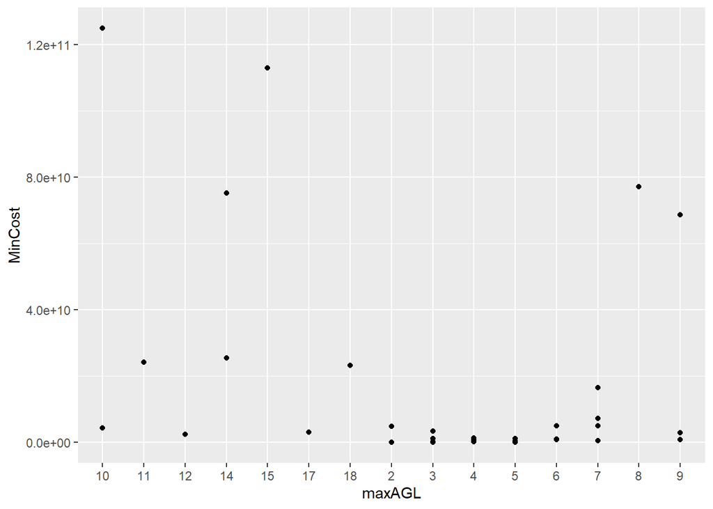

```r
Analyze_storm_data %>% ggplot(aes(x = maxAGL,y = MinCost)) + geom_point()
```

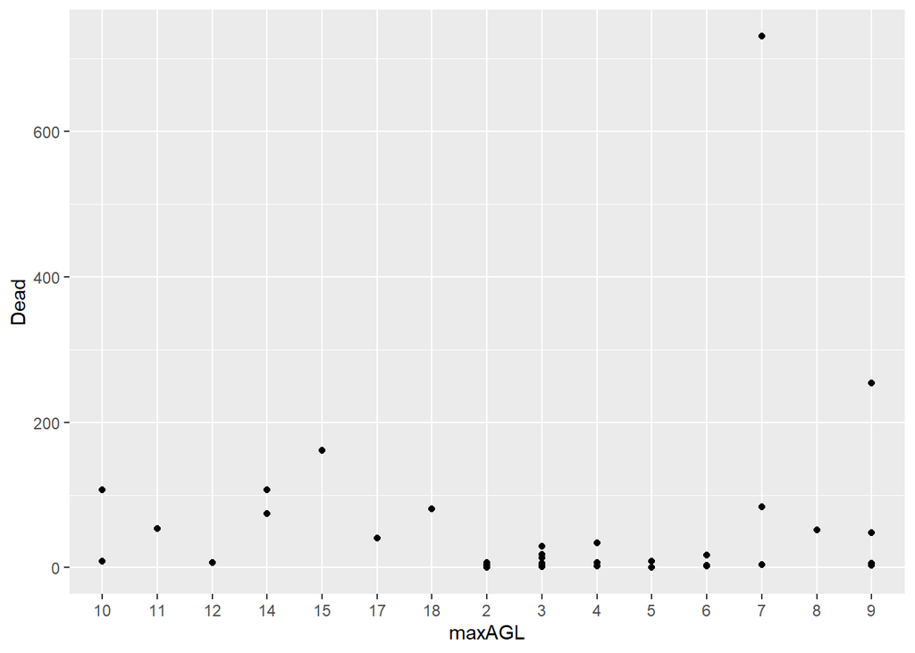

```r
Analyze_storm_data %>% ggplot(aes(x = maxAGL,y = Dead)) + geom_point()
```

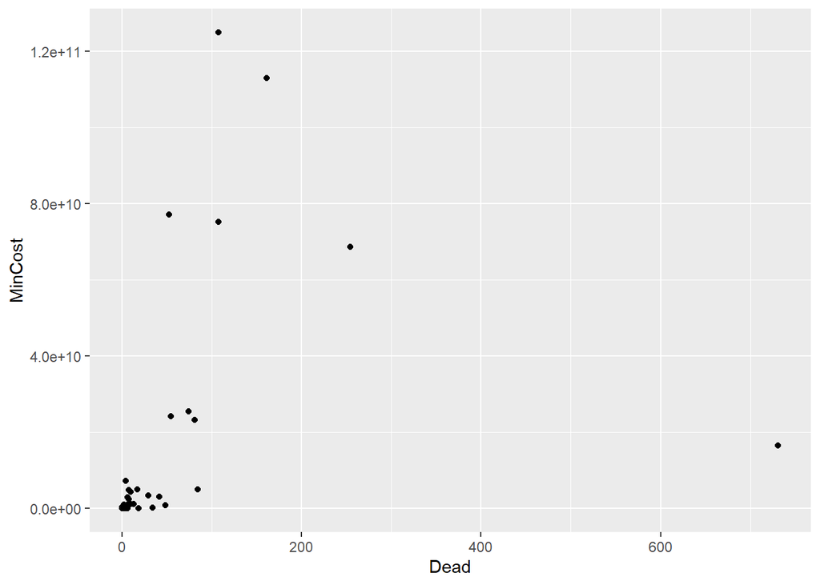

```r
Analyze_storm_data %>% ggplot(aes(x = Dead,y = MinCost)) + geom_point()
```

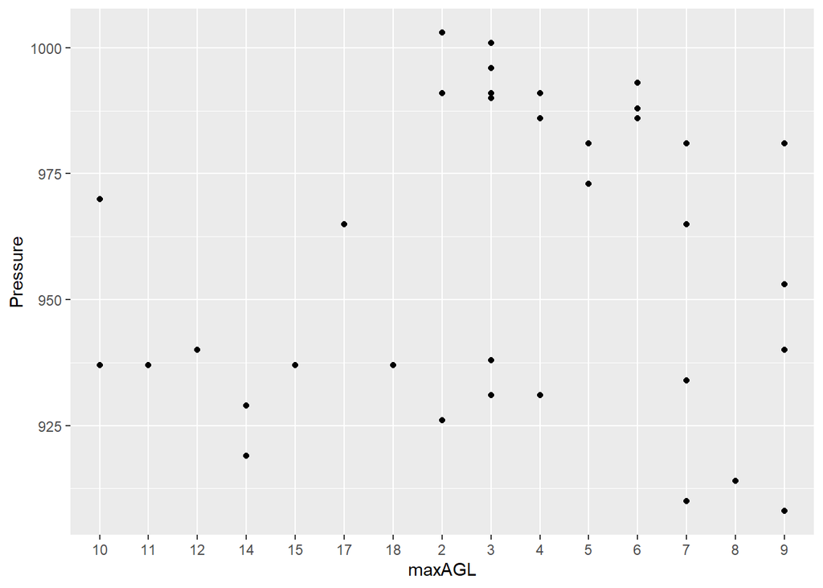

```r
Analyze_storm_data %>% ggplot(aes(x = maxAGL,y = Pressure)) + geom_point()
```

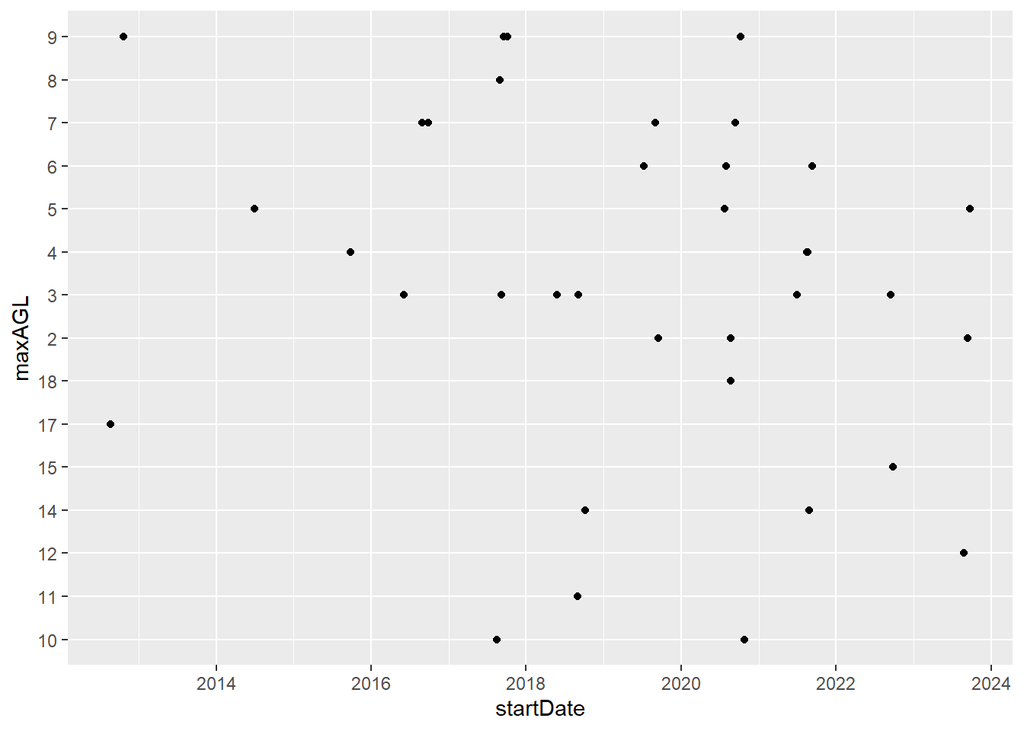

```r
Analyze_storm_data %>% ggplot(aes(x = startDate,y = maxAGL)) + geom_point()
```

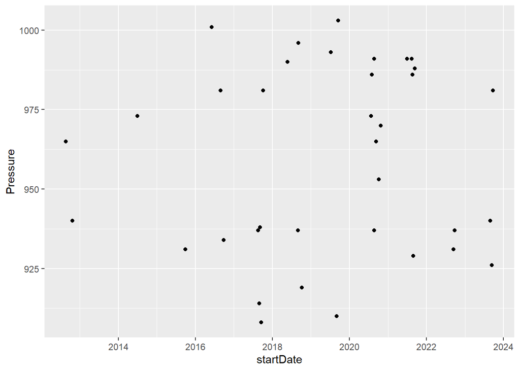

```r
Analyze_storm_data %>% ggplot(aes(x = startDate,y = Pressure)) + geom_point()
```

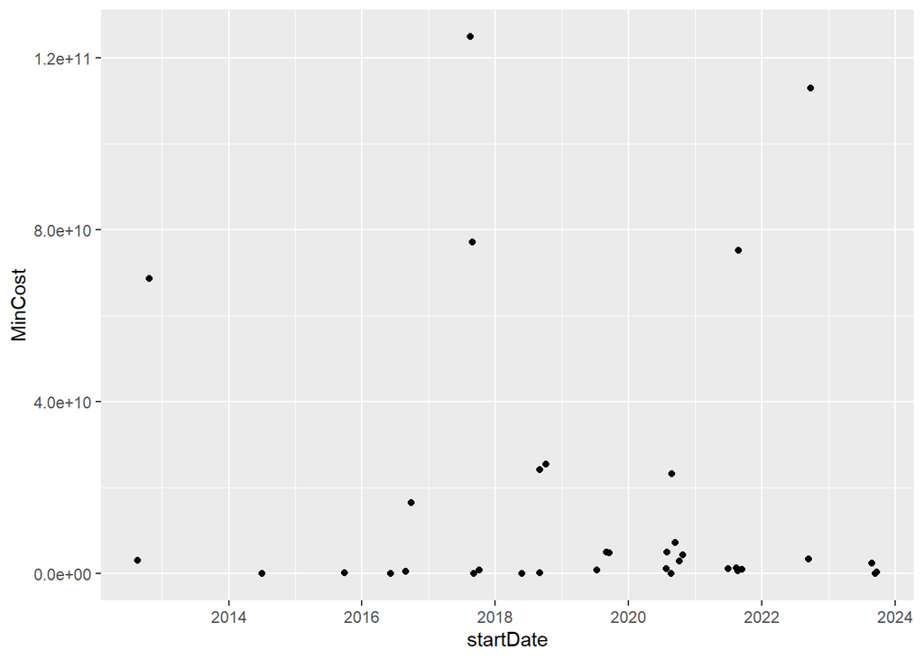

```r
Analyze_storm_data %>% ggplot(aes(x = startDate,y = MinCost)) + geom_point()
```

### Perform Categoric Analysis

We can look at number of named hurricanes per geographic area with the following bar chart. However, next steps for data cleaning could be performing a better geographic categorization of the areas, as the format is inconsistent (e.g. format is shown in region of a state, state, region of the US, and even other countries outside of the US). Instead, only a standardized format should be used, like State. This would mean that other non-US countries should be excluded from this dataset, and an understanding of the larger categories (e.g. New England) would have to be developed.

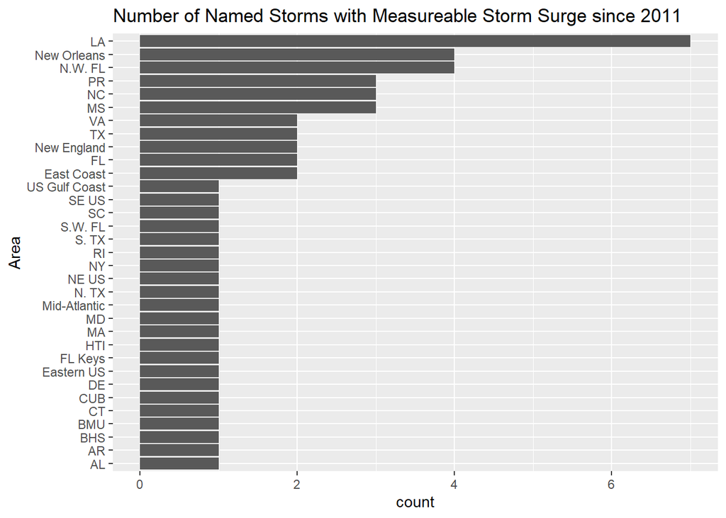

```r
count_area <- Analyze_storm_data %>%
  group_by(Area) %>%
  summarise(count = n())

count_area %>% ggplot(aes(x = count, y = reorder(Area,count))) +
  geom_col() +
  labs(title = "Number of Named Storms with Measureable Storm Surge since 2011",
       y = "Area")
```

## Buffalo Snow Dataset: Create a CSV file that includes all of the information

For my second dataset, I used the Buffalo Monthly Snowfall data from NCAA. This dataset monthly snowfall from 1940 to current day. To create the CSV file, I used BeautifulSoup to scrape the data from the NCAA website directly.

```python
import re
from bs4 import BeautifulSoup
import requests
import pandas as pd
import numpy as np

full_url = "https://www.weather.gov/buf/BuffaloSnow"
print(full_url)
page = requests.get(full_url, headers={"User-Agent": "Mozilla/5.0 (X11; CrOS x86_64 12871.102.0) AppleWebKit/537.36 (KHTML, like Gecko) Chrome/81.0.4044.141 Safari/537.36"}).text
soup = BeautifulSoup(page, "html.parser")

tags = []
index = 0

def returnTrue(tag):
    return tag.font;

allData = soup.find_all("tr")

for i in allData:
    tags.insert(len(tags),i.get_text().strip())

df = pd.DataFrame(columns = ['SEASON','JUL','AUG','SEP','OCT','NOV','DEC','JAN','FEB','MAR','APR','MAY','JUN','ANNUAL'])

for element in tags:
    row = element.strip().split('\n')
    #print(row)
    if len(row) == 14:
        df.loc[len(df)] = row


df.to_csv("buffalosnow.csv",sep =';',index=False)
```

### Approach

This dataset appears to be cleaner than the storm dataset. Some potentially problematic areas would be the use of T to indicate “Trace” and the repeated headers located in the data.

### Load Data

```r
buffalosnow <- read.csv("C:\\Users\\Kim\\Documents\\GitHub\\Data607\\Project 2\\buffalosnow.csv", header = TRUE, sep = ";")
buffalosnow
```

```
##     SEASON JUL AUG SEP  OCT  NOV  DEC  JAN  FEB  MAR  APR MAY JUN ANNUAL
## 1   SEASON JUL AUG SEP  OCT  NOV  DEC  JAN  FEB  MAR  APR MAY JUN ANNUAL
## 2  1940-41   0   0   0    T 17.5 12.1 17.3 23.1  9.3    T   0   0   79.3
## 3  1941-42   0   0   0    T  5.0  7.8 31.0 28.0 13.7  4.1   0   0   89.6
## 4  1942-43   0   0   0    T  8.7 26.7 16.9 17.7 10.4  5.1   T   0   85.5
## 5  1943-44   0   0   0  1.5 13.6  1.7  3.4 24.6 10.5  2.7   0   0   58.0
## 6  1944-45   0   0   0    0  3.9 35.1 50.6 23.3  5.8    T 2.0   0  120.7
## 7  1945-46   0   0   0    T 25.2 51.1 10.7 23.5    T    T   0   0  110.5
## 8  1946-47   0   0   0    0    T 11.9 13.0 22.2 13.5  4.0 0.8   0   65.4
## 9  1947-48   0   0   0    0  9.9  4.3 16.7  7.0  4.2    T   T   0   42.1
## 10 1948-49   0   0   0    T  1.3  7.0 11.8  5.2 14.3  0.5   0   0   40.1
## 11 1949-50   0   0   0    0 28.6  9.5 14.8 19.3 13.7  2.8   0   0   88.7
## 12  SEASON JUL AUG SEP  OCT  NOV  DEC  JAN  FEB  MAR  APR MAY JUN ANNUAL
## 13 1950-51   0   0   T    0 15.2 22.3 13.7 12.3  7.9    T   0   0   71.4
## 14 1951-52   0   0   0    T 17.7 31.6 16.8  8.9  7.4  0.6   0   0   83.0
```

[output cut: 79 more lines]

### Remove Repeated Headers

```r
buffalosnow <- buffalosnow %>% filter(SEASON != "SEASON")
```

### Replacements

Since T indicates Trace, this is effectively an unmeasureable amount of snowfall. As such, T will be replaced by 0 in the data. There is also one value listed as 2,.5 due to a data entry error (April of the 75-76 season) - this was replaced by 2.5 based on the annual snowfall for that year minus the sum of snowfall for the other months. NA values were dropped as the scraped table included future months.

```r
buffalosnow <- buffalosnow %>%
  mutate(across(everything(), ~ str_replace_all(.,"[T]","0"))) %>%
  mutate(across(everything(), ~ str_replace_all(.,"\\s","0"))) %>%
  drop_na()


buffalosnow$APR[36] <- 2.5


buffalosnow <- buffalosnow %>%
pivot_longer(c(JUL,AUG,SEP,OCT,NOV,DEC,JAN,FEB,MAR,APR,MAY,JUN,ANNUAL), names_to = "TimeCategory", values_to = "Snowfall") %>%
  mutate(Snowfall = as.numeric(Snowfall))

buffalosnow
```

```
## # A tibble: 1,092 × 3
##    SEASON  TimeCategory Snowfall
##    <chr>   <chr>           <dbl>
##  1 1940-41 JUL               0
##  2 1940-41 AUG               0
##  3 1940-41 SEP               0
##  4 1940-41 OCT               0
##  5 1940-41 NOV              17.5
##  6 1940-41 DEC              12.1
##  7 1940-41 JAN              17.3
##  8 1940-41 FEB              23.1
##  9 1940-41 MAR               9.3
## 10 1940-41 APR               0
## # ℹ 1,082 more rows
```

### Perform Categoric Analysis

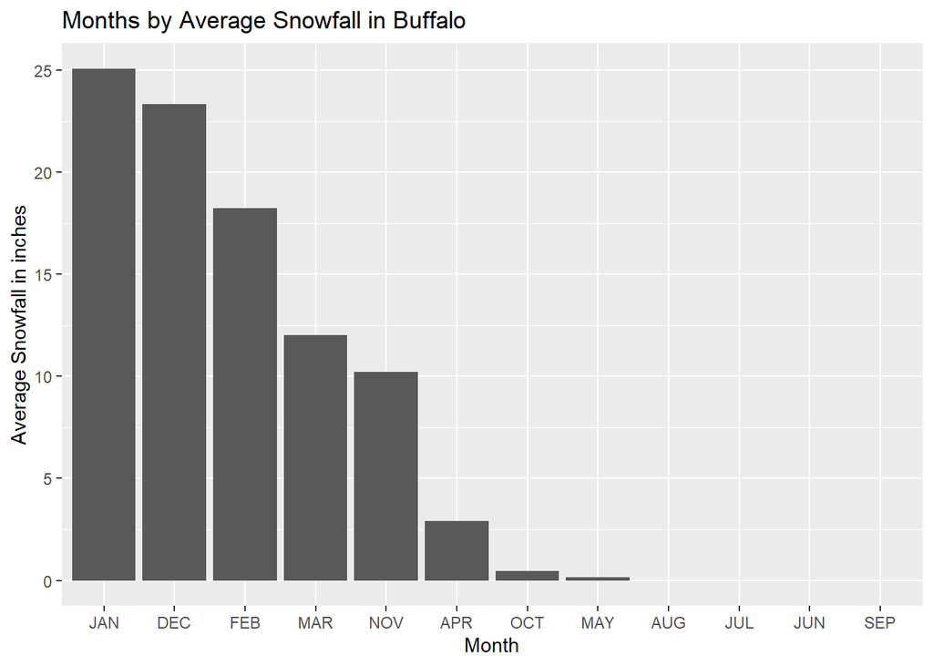

```r
buffalosnow %>% filter(TimeCategory != "ANNUAL") %>%
  group_by(TimeCategory) %>%
  summarise(averageSnowfall = mean(Snowfall)) %>%
  ggplot(aes(x = reorder(TimeCategory, -averageSnowfall), y = averageSnowfall)) +
  geom_bar(stat = "identity") +
  labs(x = "Month", y = "Average Snowfall in inches",
       title = "Months by Average Snowfall in Buffalo")
```

## Conclusion

This project provided a lot of practice using regular expressions. Most of the data cleaning involved regex to extract data from columns that contained more than one piece of information. I also had to remove and replace many data values, such as newline characters and extraneous symbols. The NOAA historic storm dataset in particular was difficult to clean given the extent of untidiness. There were also some parts of the data that were difficult to clean due to the lack of context provided in the dataset and documentation. One example is the conversion of MHHW to AGL, which did not seem like an easy task based on the information I found on Vertical Datums. Moreover, the inconsistently formatted data had proved to be a large obstacle in data cleaning, as many regex mutations on the data had to be performed due to these inconsistencies. In comparison, the NCAA Buffalo snowfall dataset was much more consistent. For next steps in data cleaning, I would propose to better characterize the geographic data in the historic storms data, as discussed in the section of categorical analysis in the NOAA section. I would also propose an additional step in the Buffalo Snowfall data, which would be to add the “correct” year to each row, as Season appears to be listed in a way that ignores calendar year. Each month could be attributed to the correct year, as the July through December months would correspond to the earlier year listed in the season while January through June would correspond to the later year listed in the season. This could be done by a conditional. “Annual” rows could also be dropped from the dataset and recalculated as necessary, but its existence in the dataset does not provide much value as the annual snowfall can be summed up easily if required; there is no reason it needs to be its own row.